# Final Fundamentos 2023

Lauro Reyes Rosas, 000213245

Sara Luz Valenzuela Camacho, 000204535

2023-12-05

*Librerías usadas*

```r
set.seed(3341)
library(dplyr)
library(tidyverse)
library(purrr)
library(invgamma)
library(cmdstanr)
library(posterior)
library(patchwork)
library(posterior)
library(knitr)
library(kableExtra)
```

Un reporte con las respuestas se deberá enviar por correo electrónico a más tardar el martes 5 a las 21:00 horas.

Instrucciones:

- En las siguientes preguntas describe tus procedimientos y escribe las respuestas explícitamente (que no haya necesidad de correr código para obtenerlas).
- Incluye el código.
- No está permitido discutir el exámen fuera de su equipo.
- Para dudas (que no deben incluir info. de la respuesta) se preguntará en el canvas del grupo.
- Consideren el material de visualización al hacer sus gráficas y reportar sus resultados.

## 1. Pruebas de hipótesis

1.1 De acuerdo a una encuesta en EUA, 26% de los residentes adultos de Illinois han terminado la preparatoria. Un investigador sospecha que este porcentaje es menor en un condado particular del estado. Obtiene una muestra aleatoria de dicho condado y encuentra que 69 de 310 personas en la muestra han completado la preparatoria. Estos resultados soportan su hipótesis? (describe tu elección de prueba de hipótesis, valor p y conclusión).

- **Nos interesa probar la hipótesis alternativa de que la proporción del condado es menor que la del estado (una cola)** $\hat p_{condado}<\hat p_{estado}$
- **Por lo que bajo la hipótesis nula ambas proporciones son iguales, esto es** $\hat p_{condado}=\hat p_{estado}$

*Estimador de máxima verosimilitud*

```r
p_hat <- 69 / 310
ee <- sqrt(p_hat * (1 - p_hat) / 310)
```

*Prueba de Walt*

```r
w <- (p_hat - 0.26) / ee
w
```

```
## [1] -1.58382
```

*Valor p*

```r
valor_p <-  (1 - pnorm(abs(w)))
cat("p-value: ",valor_p)
```

```
## p-value:  0.05661737
```

**Dado que es 0.0566 mayor a 0.05, se rechaza la hipótesis alternativa, ya que no hay mucha evidencia en contra de la hipótesis nula**

1.2 Mendel criaba chícharos de semillas lisas amarillas y de semillas corrugadas verdes. Éstas daban lugar a 4 tipos de descendientes: amarrillas lisas, amarillas corrugadas, verdes lisas y verdes corrugadas. El número de cada una es multinomial con parámetro $p=(p_1, p_2, p_3, p_4)$. De acuerdo a su teoría de herencia este vector de probabilidades es:
$$p=(9/16,3/16,3/16,1/16)$$
A lo largo de $n=556$ experimentos observó $x=(315,101,108,32)$. Utiliza la prueba de cociente de verosimilitudes para probar $H_0:p=p_0$ contra $H_0:p\ne p_0$.

**La función de probabilidad de la distribución multinomial es:**

$$P(x|\pi,n)=\binom{n!}{x_1!x_2!...x_m!}\Pi_{i=1}^{m}\pi_i^{x_i}=n!\Pi_{i=1}^{m}\frac{\pi_i^{x_i}}{x_i!}$$

**donde:** $\sum_{i=1}^kx_i=n$ **y** $\sum_{i=1}^k\pi_i=1$

**Por lo que podemos calcular la log-verosimilitud tenemos:**

$$\text{log}L(\pi)=\text{log}\Big(n!\Pi_{i=1}^{m}\frac{\pi_i^{x_i}}{x_i!}\Big)=\text{log}n!+\sum_{i=1}^mx_i\text{log}\pi_i-\sum_{i=1}^m\text{log}x_i!$$

**Para encontrar el máximo, debemos usar multiplicadores de Lagrange por las restricciones:**

$$\mathcal{L}(\mathbf{\pi},\lambda)=\text{log}L(\pi)+\lambda(1-\sum_{i=1}^m\pi_i)$$
**Derivando con respecto de** $\pi_i$

$$\frac{\partial}{\partial\pi_i}\mathcal{L}(\mathbf{\pi},\lambda)=\frac{\partial}{\partial\pi_i}\text{log}L(\mathbf{\pi})+\frac{\partial}{\partial\pi_i}\lambda(1-\sum_{i=1}^m\pi_i)
=\frac{\partial}{\partial\pi_i}\text{log}L(\mathbf{\pi})-\lambda$$
$$\frac{\partial}{\partial\pi_i}\mathcal{L}(\mathbf{\pi},\lambda)=\frac{\partial}{\partial\pi_i}\Big(\text{log}n!+\sum_{i=1}^mx_i\text{log}\pi_i-\sum_{i=1}^m\text{log}x_i!\Big)-\lambda=\frac{x_i}{\pi_i}-\lambda$$
**Igualando a cero tenemos:**

$$\pi_i=\frac{x_i}{\lambda}$$
**Para resolver para** $\lambda$, **sumamos por ambos lados**

$$1=\sum_{i=1}^m\pi_i=\sum_{i=1}^m\frac{x_i}{\lambda}=\frac{1}{\lambda}\sum_{i=1}^mx_i=\frac{1}{\lambda}n$$
**Por tanto** $\lambda=n$, **y la máxima verosimilitud es:**

$$\pi_i=\frac{x_i}{n}$$

**Con esto podemos calcular el cociente de verosimilitudes**

$$\lambda=2\text{log}\left(
\frac{L(\hat\theta)}{L(\theta_0)} \right)$$

```r
p_0 <- c(9/16, 3/16, 3/16, 1/16)
x <- c(315, 101, 108, 32)
n <- 556
H0 <- dmultinom(x, size = n, prob = p_0, log = TRUE)
# MLE
p_hat <- x / n
H1 <- dmultinom(x, size = n, prob = p_hat, log = TRUE)
lambda <- 2 * (H1 - H0)
p_value <- pchisq(lambda, df = 4, lower.tail = FALSE)
cat("p-value: ",p_value)
```

```
## p-value:  0.9758469
```

**Tenemos poca evidencia en contra de la hipótesis nula, por tanto los datos se comportan de acuerdo al vector de probabilidades de Mendel**

1.3. Sean $X_1, ...X_n \sim Poisson(\lambda)$,

- Sea $\lambda_0>0$. ¿Cuál es la prueba Wald para $H_0: \lambda = \lambda_0, H_1: \lambda \neq \lambda_0$

**La prueba de Walt es:**

$$W=\frac{\hat\lambda-\lambda_0}{\sqrt{\frac{\lambda_0}{n}}}=\sqrt{n}\frac{\hat\lambda-\lambda_0}{\sqrt{\lambda_0}}$$

**donde** $\hat\lambda$ **es el valor de máxima versimilitud**

```r
wald_poisson <- function(x, lambda_0){
  lambda_1 <- mean(x)
  se_lambda <- sqrt(lambda_1 / length(x))
  z <- (lambda_1 - lambda_0) / se_lambda
  p_value <- 2 * pnorm(-abs(z))
  p_value
}
```

- Si $\lambda_0=1$, $n=20$ y $\alpha = 0.05$. Simula $X_1, ...X_n \sim Poisson(\lambda_0)$ y realiza la prueba Wald, repite 1000 veces y registra el porcentaje de veces que rechazas $H_0$, qué tan cerca te queda el error del tipo 1 de $0.05$?

```r
set.seed(4)
lambda_0 <- 1
n <- 20
alpha <- 0.05
N <- 1000
simulations <- numeric(N)

for (i in 1:N) {
    simulations[i] <- wald_poisson(rpois(n,lambda_0),lambda_0)
}

cat("Error tipo 1: ",mean(simulations < alpha))
```

```
## Error tipo 1:  0.047
```

**Se cumple que el porcentaje de veces que rechazas $H_0$ es menor a 0.05**

## 2. Relación entre bootstrap e inferencia bayesiana

Consideremos el caso en que tenemos una única observación $x$ proveniente de una distribución normal

$$x \sim N(\theta, 1)$$

Supongamos ahora que elegimos una distribución inicial Normal.

$$\theta \sim N(0, \tau)$$

dando lugar a la distribución posterior (como vimos en la tarea)

$$\theta|x \sim N\bigg(\frac{x}{1 +
1/\tau}, \frac{1}{1+1/\tau}\bigg)$$

Ahora, entre mayor $\tau$, más se concentra la posterior en el estimador de máxima verosimilitud $\hat{\theta}=x$. En el límite, cuando $\tau \to \infty$ obtenemos una inicial no-informativa (constante) y la distribución posterior

$$\theta|x \sim N(x,1)$$

Esta posterior coincide con la distribución de bootstrap paramétrico en que generamos valores $x^*$ de $N(x,1)$, donde $x$ es el estimador de máxima verosimilitud.

Lo anterior se cumple debido a que utilizamos un ejemplo Normal pero también se cumple aproximadamente en otros casos, lo que conlleva a una correspondencia entre el bootstrap paramétrico y la inferencia bayesiana. En este caso, la distribución bootstrap representa (aproximadamente) una distribución posterior no-informartiva del parámetro de interés. Mediante la perturbación en los datos el bootstrap aproxima el efecto bayesiano de perturbar los parámetros con la ventaja de ser más simple de implementar (en muchos casos).  
*Los detalles se pueden leer en *The Elements of Statistical Learning* de Hastie y Tibshirani.

Comparemos los métodos en otro problema con el fin de apreciar la similitud en los procedimientos:

Supongamos $x_1,...,x_n \sim N(0, \sigma^2)$, es decir, los datos provienen de una distribución con media cero y varianza desconocida.

En los puntos 2.1 y 2.2 buscamos hacer inferencia del parámetro $\sigma^2$.

2.1 Bootstrap paramétrico.

- Escribe la función de log-verosimilitud y calcula el estimador de máxima verosimilitud para $\sigma^2$. Supongamos que observamos los datos `x` (en la carpeta datos), ¿Cuál es tu estimación de la varianza?

**Primero cargamos los datos**

```r
load("./data/x.RData")
```

**Luego hacemos la función generadora de la log verosimilitud, como es una normal utilizamos:**

```r
crear_log_p <- function(x){
  log_p <- function(pars){
    media = pars[1]
    desv_est = pars[2]
    # ve la ecuación del ejercicio anterior
    z <- (x - media) / desv_est
    log_verosim <- -(log(desv_est) + 0.5 * mean(z ^ 2))
    log_verosim
  }
  log_p
}
log_p <- crear_log_p(x)
```

**Después optimizamos (revisamos que converja):**

```r
res <- optim(c(0, 0.5), log_p, control = list(fnscale = -1, maxit = 1000), method = "Nelder-Mead")
res$convergence
```

```
## [1] 0
```

**Objenemos el estimador:**

```r
est_mle <- tibble(parametro = c("media", "sigma"), estimador = res$par) %>%
  column_to_rownames(var = "parametro")
est_mle3 <-est_mle
var_cuadrada <- est_mle[2,1]^2

est_mle2 <- res$par[2]^2
sigma_est=mean(x^2)
cat("varianza muestral: ",sigma_est,"; MLE: ",est_mle2)
```

```
## varianza muestral:  131.291 ; MLE:  130.7973
```

**La varianza de la muestra fue de: 131.291 ; y el MLE fue de: 130.7973**

- Aproxima el error estándar de la estimación usando **bootstrap paramétrico** y realiza un histograma de las replicaciones bootstrap.

**Primero sustituimos los parámetros en una distribución del mismo tamaño con la varianza obtenida y la media = 0**

```r
simular_modelo <- function(n, media, sigma){
  rnorm(n, media, sigma)
}
muestra_bootstrap <- simular_modelo(length(x),
                                    media = 0,
                                    est_mle["sigma", "estimador"])
head(muestra_bootstrap)
```

```
## [1] 21.886507 -9.357717  8.218999 -3.501282 -8.413633 14.421092
```

**Una vez que tenemos esta muestra bootstrap, optimizamos para recalcular los estimadores de máxima verosimlitud.**

```r
# creamos nueva verosimilitud para muestra bootstrap
log_p_boot <- crear_log_p(muestra_bootstrap)
# optimizamos
res_boot <- optim(c(0, 0.5), log_p_boot,
  control = list(fnscale = -1, maxit = 1000), method = "Nelder-Mead")
res_boot$convergence
```

```
## [1] 0
```

```r
est_mle_boot <- tibble(parametro = c("media", "sigma"), estimador = res_boot$par) %>%
  column_to_rownames(var = "parametro")
est_mle_boot[2,1]^2
```

```
## [1] 141.1032
```

**Repetimos un número grande de veces:**

```r
rep_boot <- function(rep, crear_log_p, est_mle, n){
  muestra_bootstrap <- simular_modelo(length(x),
                               media = 0,
                               est_mle["sigma", "estimador"])
  log_p_boot <- crear_log_p(muestra_bootstrap)
  # optimizamos
  res_boot <- optim(c(0, 0.5), log_p_boot,
    control = list(fnscale = -1, maxit = 1000), method = "Nelder-Mead")
  try(if(res_boot$convergence != 0) stop("No se alcanzó convergencia."))
  tibble(parametro = c("media", "sigma"), estimador_boot = res_boot$par)
}
reps_boot <- map_dfr(1:5000, ~ rep_boot(.x, crear_log_p, est_mle,
                                        n = length(muestra)), rep = ".id")
```

**estimamos el error estándar:**

```r
error_est <- reps_boot %>% group_by(parametro) %>%
  summarise(ee_boot = sd(estimador_boot))
est_fin <- bind_cols(est_mle, error_est) %>%
  mutate(across(where(is.numeric), round, 3)) %>%
  select(parametro, estimador, ee_boot)
est_fin
```

```
##       parametro estimador ee_boot
## media     media     0.560   0.996
## sigma     sigma    11.437   0.663
```

```r
est_fin[2,2]^2
```

```
## [1] 130.805
```

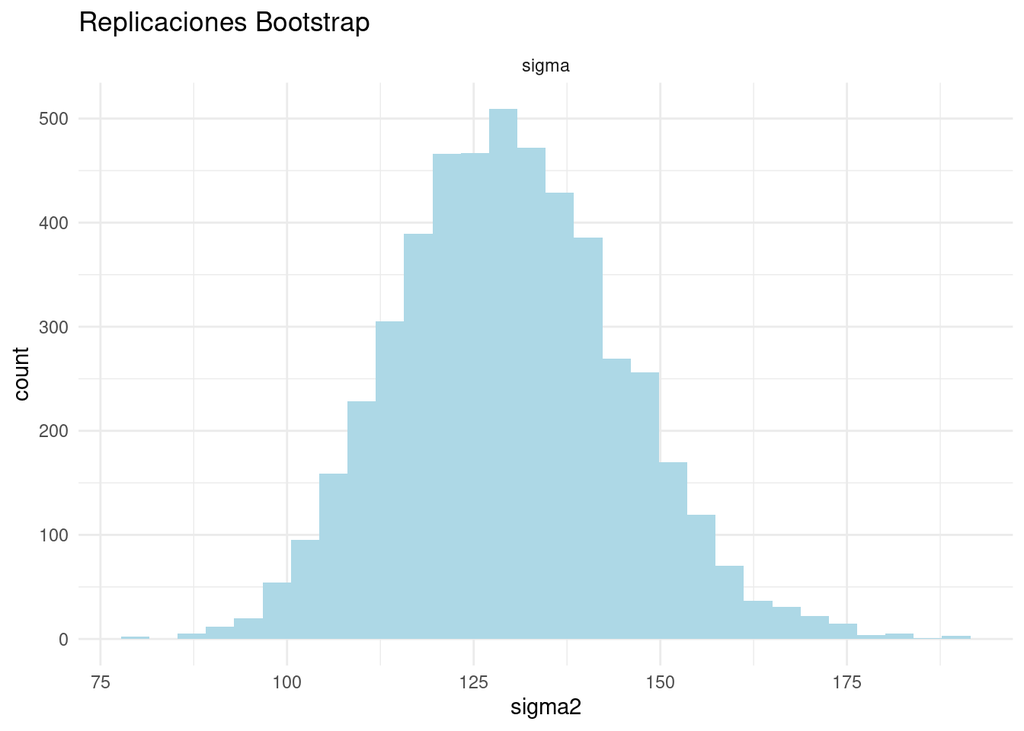

```r
sigmas2 <- reps_boot %>% filter(parametro %in% c("sigma")) %>% mutate(sigma2 = estimador_boot^2)
ggplot(sigmas2, aes(x = sigma2)) +
  geom_histogram(fill="lightblue") +facet_wrap(~parametro)+
  theme_minimal()+ labs(title = "Replicaciones Bootstrap")
```

2.2 Análisis bayesiano

- Continuamos con el problema de hacer inferencia de $\sigma^2$. Comienza especificando una inicial Gamma Inversa, justifica tu elección de los parámetros de la distribución inicial y grafica la función de densidad.

**Para elegir los parámetros, recordamos que:**

$$\alpha
=\frac{[E(\sigma^2)]^2}{var(\sigma^2)}+2$$

**y**

$$\beta=E(\sigma^2) \Bigl\{
\frac{[E(\sigma^2)]^2}{var(\sigma^2)} +1 \Bigl\}$$